# ARM and Networking

## Introducation of ARM and Networking

Association rules are “if-then” statements, that help to show the probability of relationships between data items, within large data sets in various types of databases. In data science, association rules are used to find correlations and co-occurrences between data sets. They are ideally used to explain patterns in data from seemingly independent information repositories, such as relational databases and transactional databases. The act of using association rules is sometimes referred to as “association rule mining” or “mining associations.”

Association rules are widely used in analyzing medical data set, retail industry, UX design and entertainment industry. The strength of a given association rule is measured by two main parameters: support and confidence. Support refers to how often a given rule appears in the database being mined. Confidence refers to the amount of times a given rule turns out to be true in practice. A rule may show a strong correlation in a data set because it appears very often but may occur far less when applied. This would be a case of high support, but low confidence.

Popular algorithms that use association rules include AIS, SETM, Apriori and variations of the latter. With the AIS algorithm, itemsets are generated and counted as it scans the data. The SETM algorithm also generates candidate itemsets as it scans a database, but this algorithm accounts for the itemsets at the end of its scan. With the Apriori algorithm, candidate itemsets are generated using only the large itemsets of the previous pass.

Reference: https://www.techtarget.com/searchbusinessanalytics/definition/association-rules-in-data-mining

## The Dataset Information

#### Twitter text data grabbed by Python

People’s perception of energy consumption is very important. It not only reflects the public’s perception, but also indirectly reflects people’s concern for environmental issues and their willingness to change the status quo. In the data gathering section, I have gather the text data by setting “enviornment” “clean energy” “conventional energy” “energy consumption” as the keywords for the twitter api to get the text data. In data cleaning section, I have cleaned this data by removing the unnessecery items in the text and generate a list of cleaned text. Now in this section, I will use the cleaned dataset to perform the network plot through training the ARM model to find out the relationship between words.

```python
import numpy as np
import matplotlib.pyplot as plt
import pandas as pd
from apyori import apriori
import networkx as nx
import pandas as pd
from nltk.tokenize import word_tokenize

df = pd.read_csv("/Users/crystal/Desktop/anly-501-project-HuitingSong/501-project-website/data/cleaned data/piplineresult.csv",index_col=[0])
df.head()
```

|  | 0 |
| --- | --- |
| 0 | croatian team unfair advantage consumption ara... |
| 1 | cryptopylon proud announce new token bear caso... |
| 2 | btcpriceup proud announce new token bear casol... |
| 3 | justcanadian robcairns louisgeorgevonb jasonhi... |
| 4 | bnbtracker proud announce new token bear casol... |

### Generate word token to list

```python
df = df['0']
doc = [word_tokenize(df[i]) for i in range(len(df))]
doc[0:2]
```

```
[['croatian',
  'team',
  'unfair',
  'advantage',
  'consumption',
  'arabesque',
  'gold',
  'plate',
  'steak',
  'give',
  'energy',
  'boost',
  'brazil',
  'not',
  'compete',
  'brazilian',
  'team',
  'overconfident',
  'not',
  'croatian',
  'team',
  'seriously'],
 ['cryptopylon',
  'proud',
  'announce',
  'new',
  'token',
  'bear',
  'casolcoin',
  'community',
  'token',
  'aim',
  'change',
  'energy',
  'consumption',
  'presale',
  'come',
  'soon',
  'saveearth',
  'website']]
```

## Define function to ARM and Networking

The function is based on the code reference shared by Professor J. Hickman

There are some change. Since my python announces an error of ‘list is not callable’ while training the apiorio algorithm and I found this function makes list call repeatly, I remove the list function in `reformat_results` function and later training part.

### Utility function: Re-format output

```python
def reformat_results(results):
    keep=[]
    for i in range(0,len(results)):
        for j in range(0,len(results[i])):
            if(j>1):
                for k in range(0,len(results[i][j])):
                    if(len(results[i][j][k][0])!=0):
                        rhs= results[i][j][k][0]
                        lhs= results[i][j][k][1]
                        conf= results[i][j][k][2]
                        lift= results[i][j][k][3]
                        keep.append([rhs,lhs,supp,conf,supp*conf,lift])
            if(j==1):
                supp=results[i][j]
    return pd.DataFrame(keep, columns=["rhs","lhs","supp","conf","supp*conf","lift"])
```

### Utility function: Convert to NetworkX object

```python
def convert_to_network(df):
    print(df)

    #BUILD GRAPH
    G = nx.DiGraph()  # DIRECTED
    for row in df.iterrows():
        # for column in df.columns:
        lhs="_".join(row[1][0])
        rhs="_".join(row[1][1])
        conf=row[1][3]; #print(conf)
        if(lhs not in G.nodes):
            G.add_node(lhs)
        if(rhs not in G.nodes):
            G.add_node(rhs)

        edge=(lhs,rhs)
        if edge not in G.edges:
            G.add_edge(lhs, rhs, weight=conf)

    # print(G.nodes)
    # print(G.edges)
    return G
```

### Utility function: Plot NetworkX object

```python
def plot_network(G):
    #SPECIFIY X-Y POSITIONS FOR PLOTTING
    pos=nx.random_layout(G)

    #GENERATE PLOT
    fig, ax = plt.subplots()
    fig.set_size_inches(15, 15)

    #assign colors based on attributes
    weights_e   = [G[u][v]['weight'] for u,v in G.edges()]

    #SAMPLE CMAP FOR COLORS
    cmap=plt.cm.get_cmap('Blues')
    colors_e    = [cmap(G[u][v]['weight']*10) for u,v in G.edges()]

    #PLOT
    nx.draw(
    G,
    edgecolors="black",
    edge_color=colors_e,
    node_size=2000,
    linewidths=2,
    font_size=8,
    font_color="white",
    font_weight="bold",
    width=weights_e,
    with_labels=True,
    pos=pos,
    ax=ax
    )
    ax.set(title='Dracula')
    plt.show()
```

## Call the function

### train the ARM model by apriori

```python
# INSERT CODE TO TRAIN THE ARM MODEL USING THE "apriori" PACKAGE
print("Transactions:",pd.DataFrame(doc).head())
results = [*apriori(doc, min_support=0.1)]     #RUN APRIORI ALGORITHM
res = reformat_results(results)
print(res.shape)
```

```
Transactions:              0          1                2            3            4   \
0      croatian       team           unfair    advantage  consumption
1   cryptopylon      proud         announce          new        token
2    btcpriceup      proud         announce          new        token
3  justcanadian  robcairns  louisgeorgevonb  jasonhickel            x
4    bnbtracker      proud         announce          new        token

            5          6          7            8     9   ...    22    23  \
0    arabesque       gold      plate        steak  give  ...  None  None
1         bear  casolcoin  community        token   aim  ...  None  None
2         bear  casolcoin  community        token   aim  ...  None  None
3  interesting    primary     energy  consumption  hour  ...  None  None
4         bear  casolcoin  community        token   aim  ...  None  None

     24    25    26    27    28    29    30    31
0  None  None  None  None  None  None  None  None
1  None  None  None  None  None  None  None  None
2  None  None  None  None  None  None  None  None
3  None  None  None  None  None  None  None  None
4  None  None  None  None  None  None  None  None

[5 rows x 32 columns]
```

```
(523270, 6)
```

### plot the Network-x

```
              rhs            lhs   supp      conf  supp*conf      lift
0      (actually)    (alongside)  0.225  1.000000   0.225000  4.444444
1     (alongside)     (actually)  0.225  1.000000   0.225000  4.444444
2      (actually)     (approach)  0.225  1.000000   0.225000  4.444444
3      (approach)     (actually)  0.225  1.000000   0.225000  4.444444
4      (actually)     (caffeine)  0.225  1.000000   0.225000  4.255319
5      (caffeine)     (actually)  0.225  0.957447   0.215426  4.255319
6      (actually)        (drink)  0.225  1.000000   0.225000  3.463203
7         (drink)     (actually)  0.225  0.779221   0.175325  3.463203
8      (actually)       (energy)  0.225  1.000000   0.225000  1.098901
9        (energy)     (actually)  0.225  0.247253   0.055632  1.098901
10     (actually)         (give)  0.225  1.000000   0.225000  4.255319
11         (give)     (actually)  0.225  0.957447   0.215426  4.255319
12     (actually)  (hubermanlab)  0.225  1.000000   0.225000  4.255319
13  (hubermanlab)     (actually)  0.225  0.957447   0.215426  4.255319
14     (actually)       (jitter)  0.225  1.000000   0.225000  4.444444
15       (jitter)     (actually)  0.225  1.000000   0.225000  4.444444
16     (actually)           (mg)  0.225  1.000000   0.225000  4.444444
17           (mg)     (actually)  0.225  1.000000   0.225000  4.444444
18     (actually)           (rt)  0.225  1.000000   0.225000  1.975309
19           (rt)     (actually)  0.225  0.444444   0.100000  1.975309
20     (actually)     (theanine)  0.225  1.000000   0.225000  4.444444
21     (theanine)     (actually)  0.225  1.000000   0.225000  4.444444
22    (alongside)     (approach)  0.225  1.000000   0.225000  4.444444
23     (approach)    (alongside)  0.225  1.000000   0.225000  4.444444
24    (alongside)     (caffeine)  0.225  1.000000   0.225000  4.255319
```

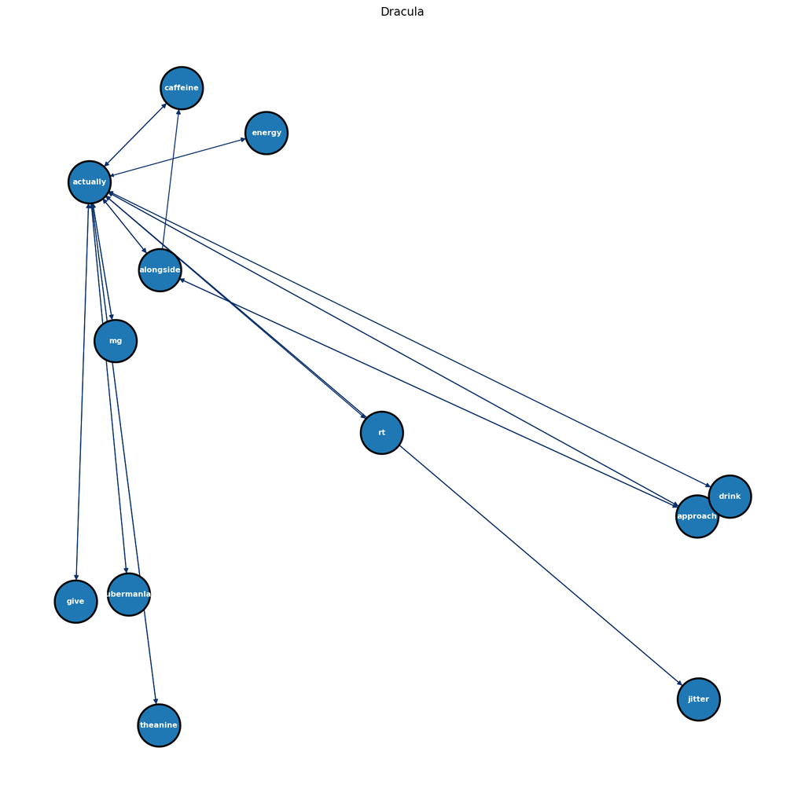

```python
# INSERT CODE TO PLOT THE RESULTS AS A NETWORK-X OBJECT
G=convert_to_network(res[0:25])
plot_network(G)
```

Now, we can see the word relationship. Most of the words shown in the network graph have no understandable meaning, but I notice `energy` has relation with `actually`. This weird relationship and I had no idea what this means. The probable reasons for making this unreabable result is the dataset have lots of dirty words. People in twitter can have free speech and I do not have the algorithm to deal with the meaningless word. For future study, I hope i can have solution for this problem and can figure out the real Network relationship.